# 4. Estadio de inmunidad pasiva

Max Orozco Carstensen

2023-10-12

La inmunidad pasiva consiste en la transferencia de inmunidad activa en la forma de anticuerpos de un individuo a otro. La inmunidad pasiva puede suceder de forma natural, por ejemplo, por la vía materna al feto a través de la placenta o al bebé vía la leche materna. El estadio de inmunidad pasiva se denota por la variable $M(t)$ y se añade al sistema antes de que los individuos sean suceptibles. El siguiente modelo **MSIR** se describe con las siguientes ecuaciones diferenciales.

$$\dot M = \nu - \rho M - \mu M$$
$$\dot S = \rho M - \beta S I - \mu S$$
$$\dot I = \beta S I - (\alpha +
\mu) I$$
$$\dot R = \alpha I - \mu
R$$

1. **¿Bajo qué condiciones se puede inducir de forma artificial la inmunidad pasiva?**

A través de vacunas que confieran inmunidad por poco tiempo, en lo que el sistema inmune del individuo madura lo suficiente como para tener una respuesta propia; por ejemplo, las vacunas anti-toxinas para el veneno de algún animal.

2. **Dibuja el esquema por compartimentos que representa este conjunto de ecuaciones**

[figure not shown]

3. **Explica el significado de cada ecuación: es decir, explica el significado de cada término y cada parámetro. ¿Existen parámetros que están acotados?, si es así, indica el intervalo en donde pueden variar.**
- $\nu$: Tasa de nacimientos o individuos que entran al sistema.
- $\rho$: Tasa en la que los individuos pierden la inmunidad pasiva y entran a los susceptibles.
- $\beta$: Tasa de interacción entre susceptibles e infectados.
- $\mu$: Tasa de muertes o individuos que salen del sistema.
- $\alpha$: Tasa en la que los infectados se recuperan.

Todas las tasas son acotadas, debido a que es $1/tiempo$.

*Inmunidad pasiva*

Favorece:

- $\nu$: Individuos que nacen o entran al sistema.

Afecta:

- $\rho M$: Individuos que pierden la inmunidad pasiva.
- $\mu M$: Individuos con inmunidad pasiva que mueren o salen del sistema.

*Susceptibles*:

Favorece:

- $\rho M$: Individuos que pierden la inmunidad pasiva.

Afecta:

- $\beta SI$: Interacción entre susceptibles e infectados.
- $\mu S$: Individuos susceptibles que mueren o salen del sistema.

*Infectados:*

Favorece:

- $\beta SI$: Interacción entre susceptibles e infectados.

Afecta:

- $\alpha I$: Individuos infectados que se recuperan.
- $\mu I$: Individuos infectados que mueren o salen del sistema.

*Recuperados:*

Favorece:

- $\alpha I$: Individuos infectados que se recuperan.

Afecta:

- $\mu R$: Individuos recuperados que mueren o salen del sistema.
4. **¿Bajo qué condiciones la población se conservaría?**

La población se conservaría si la suma de las tasas de muerte es igual a la tasa de nacimientos.

$$\nu = (\mu M + \mu S + \mu I + \mu
R)$$

5. **Encuentra, si existe, el punto de equilibrio *free-disease***

Debido a que el modelo *free-disease* hace referencia a que no hay individuos infectados, con esa misma premisa, no puede haber individuos recuperados, únicamente susceptibles y con inmunidad pasiva. Si se igualan esas condiciones a 0, queda:

$$\dot M = \nu - \rho M - \mu M = \nu -
\mu M = \nu/\mu = M$$
$$\dot S = \rho
(\nu/\mu) - \beta S 0 - \mu S = \rho (\nu/\mu) - \mu S = \rho (\nu/\mu)
/ \mu$$
$$\dot I = \beta S 0 -
(\alpha + \mu) 0 = 0$$
$$\dot R =
\alpha 0 - \mu 0 = 0$$

Por lo tanto, el punto de equilibrio *free-disease* sería: $(M, S, I, R) = (\nu / \mu, \rho (\nu/\mu) / \mu, 0, 0)$

6. **¿Qué tipo de enfermedad puede estar describiendo? Justifica tu respuesta.**

Hepatitis A y/o B, en donde se pueden recibir anticuerpos a través de la madre, pero también a través de vacunas (que se ponen de recién nacidx). Otro ejemplo, como mencioné anteriormente, pero que no es una enfermedad como tal, son las vacunas preventivas para mordidas de serpiente.

7. **Selecciona un conjunto de parámetros adecuados y resuelve numéricamente el sistema de ecuaciones diferenciales. Asegúrate que tu solución alcance un punto de equilibrio.Discute tu resultado.**

```r
library (deSolve)

MSIR <- function (time, state, parameters) {
  with (as.list (c (state, parameters)), {
    dM <- nu - rho * M - muM
    dS <- rho * M - beta * S * I - muS
    dI <-  beta * S * I - alpha * I - muI
    dR <- alpha * I - muR
    list (c (dM, dS, dI, dR))
  })
}

parameters <- c (nu = 1, rho = 0.4, beta = 0.5, alpha = 0.3, muM = 0.2, muS = 0.4, muI = 0.5, muR = 0.1)
initial_conditions <- c (M = 500, S = 50, I = 70, R = 30)
time <- seq (0, 110, by = 0.001)
out <- ode (initial_conditions, time, MSIR, parameters)
```

[output not shown]

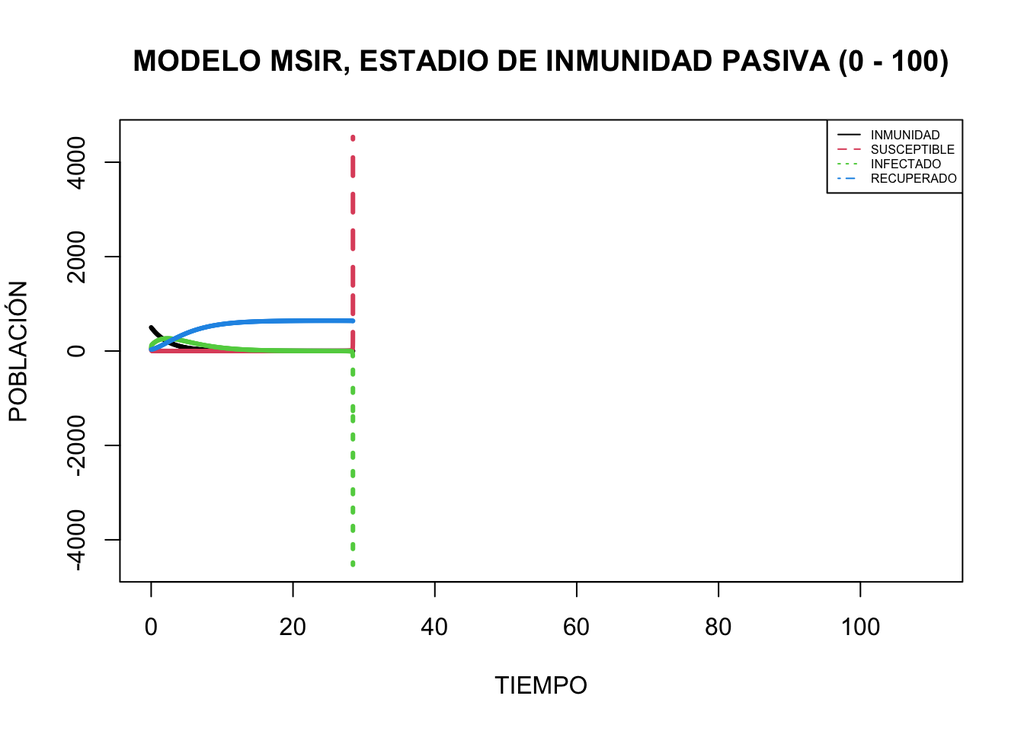

```r
matplot (out [ , 1], out [ , 2 : 5], type = "l", xlab = "TIEMPO", ylab = "POBLACIÓN", main = "MODELO MSIR, ESTADIO DE INMUNIDAD PASIVA (0 - 100)", lwd = 3)
legend ("topright", c ("INMUNIDAD", "SUSCEPTIBLE", "INFECTADO", "RECUPERADO"), col = 1 : 4, lty = 1 : 5, cex = 0.5)
```

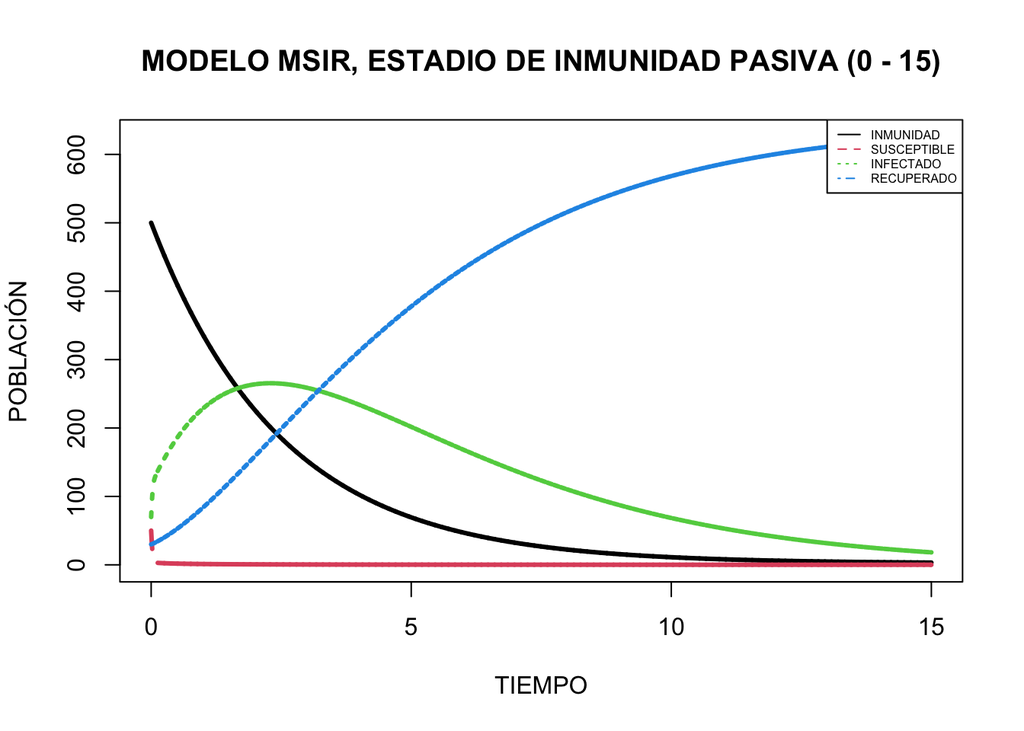

```r
parameters <- c (nu = 1, rho = 0.4, beta = 0.5, alpha = 0.3, muM = 0.2, muS = 0.4, muI = 0.5, muR = 0.1)
initial_conditions <- c (M = 500, S = 50, I = 70, R = 30)
time <- seq (0, 15, by = 0.001)
out <- ode (initial_conditions, time, MSIR, parameters)

matplot (out [ , 1], out [ , 2 : 5], type = "l", xlab = "TIEMPO", ylab = "POBLACIÓN", main = "MODELO MSIR, ESTADIO DE INMUNIDAD PASIVA (0 - 15)", lwd = 3)
legend ("topright", c ("INMUNIDAD", "SUSCEPTIBLE", "INFECTADO", "RECUPERADO"), col = 1 : 4, lty = 1 : 5, cex = 0.5)
```